# Reproducible Research Course Project 2

**February 23, 2021**

**Emirrio Renaldie Hartland**

## U.S. National Oceanic and Atmospheric Administration’s (NOAA) Storm Database - Health and Economic Impacts

### Synopsis

This is the second peer assessment project of the Reproducible Research course at Coursera.

#### Introduction

Storms and other severe weather events can cause both public health and economic problems for communities and municipalities. Many severe events can result in fatalities, injuries, and property damage, and preventing such outcomes to the extent possible is a key concern.

This project involves exploring the U.S. National Oceanic and Atmospheric Administration’s (NOAA) storm database. This database tracks characteristics of major storms and weather events in the United States, including when and where they occur, as well as estimates of any fatalities, injuries, and property damage.

#### Questions

1. Across the United States, which types of events (as indicated in the EVTYPE variable) are most harmful with respect to population health?
2. Across the United States, which types of events have the greatest economic consequences?

#### Summary

Based on the data analysis, tornado is considered as the most harmful weather event in the United States, with respect to population health (by measuring the fatalities and injuries variables). On the other hand, flood has the greatest economic consequences across the United States, as measured by the property damages and the crop damages.

### Data Processing

#### Data

The data for this assignment come in the form of a comma-separated-value file compressed via the bzip2 algorithm to reduce its size. You can download the file from the course web site:

- [Storm Data](https://d396qusza40orc.cloudfront.net/repdata%2Fdata%2FStormData.csv.bz2) [47Mb]

There is also some documentation of the database available. Here you will find how some of the variables are constructed/defined.

- National Weather Service [Storm Data Documentation](https://d396qusza40orc.cloudfront.net/repdata%2Fpeer2_doc%2Fpd01016005curr.pdf)
- National Climatic Data Center Storm Events [FAQ](https://d396qusza40orc.cloudfront.net/repdata%2Fpeer2_doc%2FNCDC%20Storm%20Events-FAQ%20Page.pdf)

The events in the database start in the year 1950 and end in November 2011. In the earlier years of the database there are generally fewer events recorded, most likely due to a lack of good records. More recent years should be considered more complete.

#### Loading the data

```r
library(data.table)
library(ggplot2)

data <- read.csv("repdata_data_StormData.csv", header = TRUE, sep=",")
```

#### Examining the data

```r
dim(data)
```

```
## [1] 902297     37
```

```r
str(data)
```

```
## 'data.frame':    902297 obs. of  37 variables:
##  $ STATE__   : num  1 1 1 1 1 1 1 1 1 1 ...
##  $ BGN_DATE  : Factor w/ 16335 levels "1/1/1966 0:00:00",..: 6523 6523 4242 11116 2224 2224 2260 383 3980 3980 ...
##  $ BGN_TIME  : Factor w/ 3608 levels "00:00:00 AM",..: 272 287 2705 1683 2584 3186 242 1683 3186 3186 ...
##  $ TIME_ZONE : Factor w/ 22 levels "ADT","AKS","AST",..: 7 7 7 7 7 7 7 7 7 7 ...
##  $ COUNTY    : num  97 3 57 89 43 77 9 123 125 57 ...
##  $ COUNTYNAME: Factor w/ 29601 levels "","5NM E OF MACKINAC BRIDGE TO PRESQUE ISLE LT MI",..: 13513 1873 4598 10592 4372 10094 1973 23873 24418 4598 ...
##  $ STATE     : Factor w/ 72 levels "AK","AL","AM",..: 2 2 2 2 2 2 2 2 2 2 ...
##  $ EVTYPE    : Factor w/ 985 levels "   HIGH SURF ADVISORY",..: 834 834 834 834 834 834 834 834 834 834 ...
##  $ BGN_RANGE : num  0 0 0 0 0 0 0 0 0 0 ...
##  $ BGN_AZI   : Factor w/ 35 levels "","  N"," NW",..: 1 1 1 1 1 1 1 1 1 1 ...
##  $ BGN_LOCATI: Factor w/ 54429 levels "","- 1 N Albion",..: 1 1 1 1 1 1 1 1 1 1 ...
##  $ END_DATE  : Factor w/ 6663 levels "","1/1/1993 0:00:00",..: 1 1 1 1 1 1 1 1 1 1 ...
##  $ END_TIME  : Factor w/ 3647 levels ""," 0900CST",..: 1 1 1 1 1 1 1 1 1 1 ...
##  $ COUNTY_END: num  0 0 0 0 0 0 0 0 0 0 ...
```

[output cut: 23 more lines]

#### Subsetting the data

From a list of variables in **data**, these are the columns of interest:

Population health variables:

- FATALITIES: approx. number of deaths
- INJURIES: approx. number of injuries

Economic variables:

- PROPDMG: approx. property damags
- PROPDMGEXP: the units for property damage value
- CROPDMG: approx. crop damages
- CROPDMGEXP: the units for crop damage value

Events - target variable:

- EVTYPE: weather event (Tornados, Wind, Snow, Flood, etc..)

Subset variables of interest from the original data set:

```r
vars <- c('EVTYPE', 'FATALITIES', 'INJURIES', 'PROPDMG', 'PROPDMGEXP', 'CROPDMG', 'CROPDMGEXP')
data <- data[, vars]
summary(data)
```

```
##                EVTYPE         FATALITIES          INJURIES
##  HAIL             :288661   Min.   :  0.0000   Min.   :   0.0000
##  TSTM WIND        :219940   1st Qu.:  0.0000   1st Qu.:   0.0000
##  THUNDERSTORM WIND: 82563   Median :  0.0000   Median :   0.0000
##  TORNADO          : 60652   Mean   :  0.0168   Mean   :   0.1557
##  FLASH FLOOD      : 54277   3rd Qu.:  0.0000   3rd Qu.:   0.0000
##  FLOOD            : 25326   Max.   :583.0000   Max.   :1700.0000
##  (Other)          :170878
##     PROPDMG          PROPDMGEXP        CROPDMG          CROPDMGEXP
##  Min.   :   0.00          :465934   Min.   :  0.000          :618413
##  1st Qu.:   0.00   K      :424665   1st Qu.:  0.000   K      :281832
##  Median :   0.00   M      : 11330   Median :  0.000   M      :  1994
##  Mean   :  12.06   0      :   216   Mean   :  1.527   k      :    21
##  3rd Qu.:   0.50   B      :    40   3rd Qu.:  0.000   0      :    19
##  Max.   :5000.00   5      :    28   Max.   :990.000   B      :     9
##                    (Other):    84                     (Other):     9
```

Subset variables of interest where fatalities, injuries, or damages occured:

```r
data <- as.data.table(data)
data <- data[(EVTYPE != "?" & (INJURIES > 0 | FATALITIES > 0 | PROPDMG > 0 | CROPDMG > 0)),
        c("EVTYPE", "FATALITIES", "INJURIES", "PROPDMG", "PROPDMGEXP", "CROPDMG", "CROPDMGEXP")]
```

The units of property damage and crop damage need to be converted by the following rules:

- K or k: thousand dollars (10^3)
- M or m: million dollars (10^6)
- B or b: billion dollars (10^9)

Transform the PROPDMGEXP and CROPDMGEXP variables:

```r
cols <- c("PROPDMGEXP", "CROPDMGEXP")
data[,  (cols) := c(lapply(.SD, toupper)), .SDcols = cols]

trans.PROPDMG <-  c("\"\"" = 10^0,
                 "-" = 10^0, "+" = 10^0, "0" = 10^0, "1" = 10^1, "2" = 10^2, "3" = 10^3,
                 "4" = 10^4, "5" = 10^5, "6" = 10^6, "7" = 10^7, "8" = 10^8, "9" = 10^9,
                 "H" = 10^2, "K" = 10^3, "M" = 10^6, "B" = 10^9)
trans.CROPDMG <-  c("\"\"" = 10^0, "?" = 10^0, "0" = 10^0, "K" = 10^3, "M" = 10^6, "B" = 10^9)

data[, PROPDMGEXP := trans.PROPDMG[as.character(data[,PROPDMGEXP])]]
data[is.na(PROPDMGEXP), PROPDMGEXP := 10^0 ]

data[, CROPDMGEXP := trans.CROPDMG[as.character(data[,CROPDMGEXP])] ]
data[is.na(CROPDMGEXP), CROPDMGEXP := 10^0 ]
```

Combining the coefficient and exponent part of property damage and crop damage:

```r
data <- data[, .(EVTYPE, FATALITIES, INJURIES, PROPDMG, PROPDMGEXP, PROPCOST = PROPDMG * PROPDMGEXP, CROPDMG, CROPDMGEXP, CROPCOST = CROPDMG * CROPDMGEXP)]
```

### Data Analysis

#### Estimating the total population health variables (fatalities and injuries)

```r
pop_health <- data[, .(FATALITIES = sum(FATALITIES), INJURIES = sum(INJURIES), TOTAL_HEALTH = sum(FATALITIES) + sum(INJURIES)), by = .(EVTYPE)]

pop_health <- pop_health[order(-TOTAL_HEALTH), ]

pop_health <- pop_health[1:10, ]

head(pop_health, 10)
```

```
##                EVTYPE FATALITIES INJURIES TOTAL_HEALTH
##  1:           TORNADO       5633    91346        96979
##  2:    EXCESSIVE HEAT       1903     6525         8428
##  3:         TSTM WIND        504     6957         7461
##  4:             FLOOD        470     6789         7259
##  5:         LIGHTNING        816     5230         6046
##  6:              HEAT        937     2100         3037
##  7:       FLASH FLOOD        978     1777         2755
##  8:         ICE STORM         89     1975         2064
##  9: THUNDERSTORM WIND        133     1488         1621
## 10:      WINTER STORM        206     1321         1527
```

#### Estimating the total economic variables (propert and crop damage)

```r
economic <- data[, .(PROPCOST = sum(PROPCOST), CROPCOST = sum(CROPCOST), TOTAL_ECONOMIC = sum(PROPCOST) + sum(CROPCOST)), by = .(EVTYPE)]

economic <- economic[order(-TOTAL_ECONOMIC), ]

economic <- economic[1:10, ]

head(economic, 10)
```

```
##                EVTYPE     PROPCOST    CROPCOST TOTAL_ECONOMIC
##  1:             FLOOD 144657709807  5661968450   150319678257
##  2: HURRICANE/TYPHOON  69305840000  2607872800    71913712800
##  3:           TORNADO  56947380677   414953270    57362333947
##  4:       STORM SURGE  43323536000        5000    43323541000
##  5:              HAIL  15735267513  3025954473    18761221986
##  6:       FLASH FLOOD  16822673979  1421317100    18243991079
##  7:           DROUGHT   1046106000 13972566000    15018672000
##  8:         HURRICANE  11868319010  2741910000    14610229010
##  9:       RIVER FLOOD   5118945500  5029459000    10148404500
## 10:         ICE STORM   3944927860  5022113500     8967041360
```

### Results

#### Accross the United States, tornado is the most harmful event with respect to population health

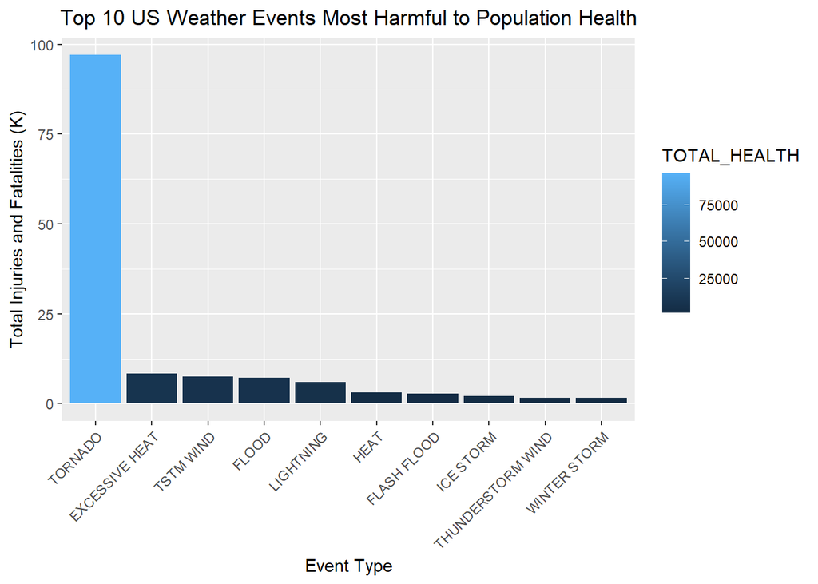

```r
ggplot(pop_health, aes(x = reorder(EVTYPE, -TOTAL_HEALTH), y = TOTAL_HEALTH/1e3)) +
  geom_bar(stat = "identity", aes(fill = TOTAL_HEALTH), position = "dodge") +
  ylab("Total Injuries and Fatalities (K)") +
  xlab("Event Type") +
  theme(axis.text.x = element_text(angle=45, hjust=1)) +
  ggtitle("Top 10 US Weather Events Most Harmful to Population Health") +
  theme(plot.title = element_text(hjust = 0.5))
```

#### Accross the United States, flood has the greatest economic consequences

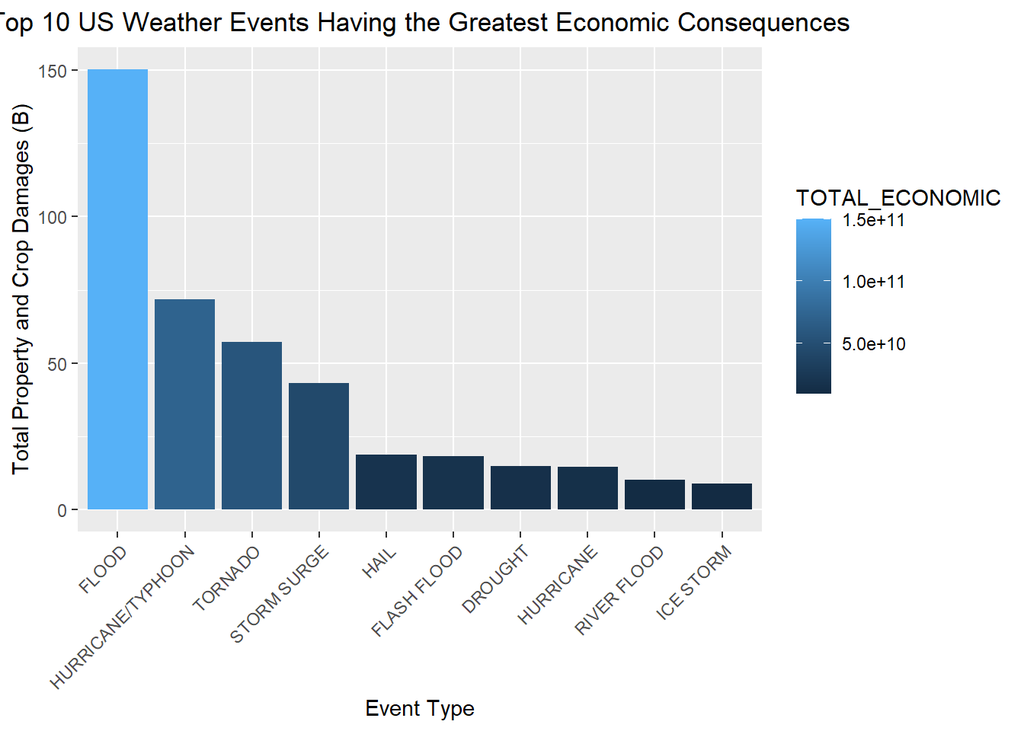

```r
ggplot(economic, aes(x = reorder(EVTYPE, -TOTAL_ECONOMIC), y = TOTAL_ECONOMIC/1e9)) +
  geom_bar(stat = "identity", aes(fill = TOTAL_ECONOMIC), position = "dodge") +
  ylab("Total Property and Crop Damages (B)") +
  xlab("Event Type") +
  theme(axis.text.x = element_text(angle=45, hjust=1)) +
  ggtitle("Top 10 US Weather Events Having the Greatest Economic Consequences") +
  theme(plot.title = element_text(hjust = 0.5))
```